# Estudio_igraph

Fernando Alvarado

2025-03-07

# Grafica a partir de una tabla de correlacion

**Objetivo**

El objetivo es poder pasar de datos, a una tabla de correlaciones y luego a una grafica de correlaciones donde solo grafiquemos las que nos interesan y podamos ver su relacion entre si.

Los datos de este grafo son datos de liga europea de futbol, para hacer la grafica primero haremos una tabla de correlacion y luego veremos las correlacion mayores de 0.5 o menemos a -0.5.

Nuestros datos contiene la tabla de posiciones de la Liga Premier de Inglaterra de la temporada 2019-2020. contando con los siguientes campos **Team**, **W** *(wins)*, **D** *(draws)* ,**L** *(losses)* , **GF** *(goals for)* , **GA** *(goals against)* , **GD** *(goal difference)*

```r
# Cargamos los datos de un .txt

setwd("C:/Users/ferna/Documents/Servicio/Estudio/Data")

data <- read.table("EPL_19_20.txt", header = TRUE, sep = ",")
```

```
##             Team  W  D  L  GF GA GD
## 1      Liverpool 32  3  3  85 33 52
## 2      Man. City 26  3  9 102 35 67
## 3    Man. United 18 12  8  66 36 30
## 4        Chelsea 20  6 12  69 54 15
## 5 Leicester City 18  8 12  67 41 26
## 6      Tottenham 16 11 11  61 47 14
```

```
##        W D     L    GF    GA    GD
## W   1.00 0 -0.86  0.91 -0.80  0.93
## D   0.00 1  0.00  0.00  0.00  0.00
## L  -0.86 0  1.00 -0.75  0.93 -0.89
## GF  0.91 0 -0.75  1.00 -0.69  0.95
## GA -0.80 0  0.93 -0.69  1.00 -0.88
## GD  0.93 0 -0.89  0.95 -0.88  1.00
```

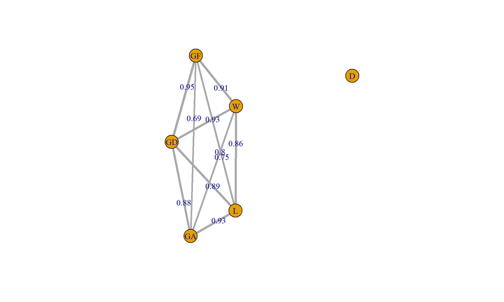

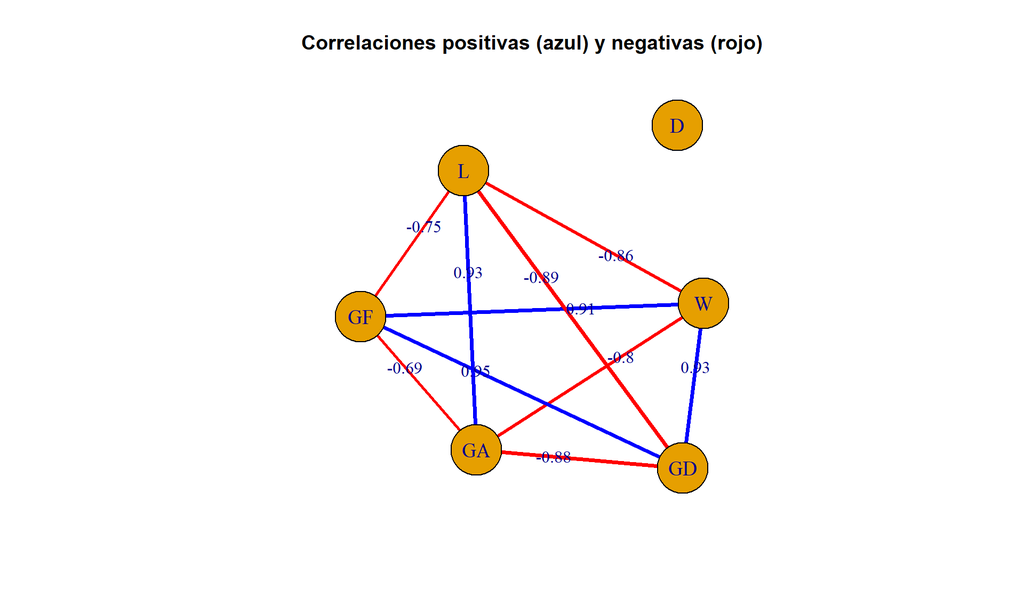

# Leyendo datos de una isla en Nueva Zelanda

**Información general:**  
Este conjunto de estudios se llevó a cabo en ríos de Nueva Zelanda, Maine y Carolina del Norte (EE.UU.). Los datos corresponden a redes tróficas utilizadas para comparar el efecto del uso del suelo sobre la estructura de las redes alimentarias a nivel regional y continental (Townsend et al. 1998, Thompson y Townsend 2003). También han sido objeto de reanálisis en cuanto a esfuerzo de muestreo, resolución taxonómica y variabilidad estacional.

**Tipo de datos:**  
Los autores registraron insectos acuáticos, algas y peces, junto con sus interacciones tróficas. Los datos se presentan como una **matriz binaria de interacciones**, donde un “1” indica interacción trófica entre un par de especies y un “0” indica ausencia de interacción.

```
## [1] 58 58
```

```
##   V1 V2 V3 V4 V5 V6 V7 V8 V9 V10
## 1  0  0  0  0  0  0  0  0  0   0
## 2  0  0  0  0  0  0  0  0  0   0
## 3  0  0  0  0  0  0  0  0  0   0
## 4  0  0  0  0  0  0  0  0  0   0
## 5  0  0  0  0  0  0  0  0  0   0
## 6  0  0  0  0  0  0  0  0  0   0
```

```
## [1] 58 58
```

Haciendo una primera grafica sencilla de nuestra amtriz de ayacencia

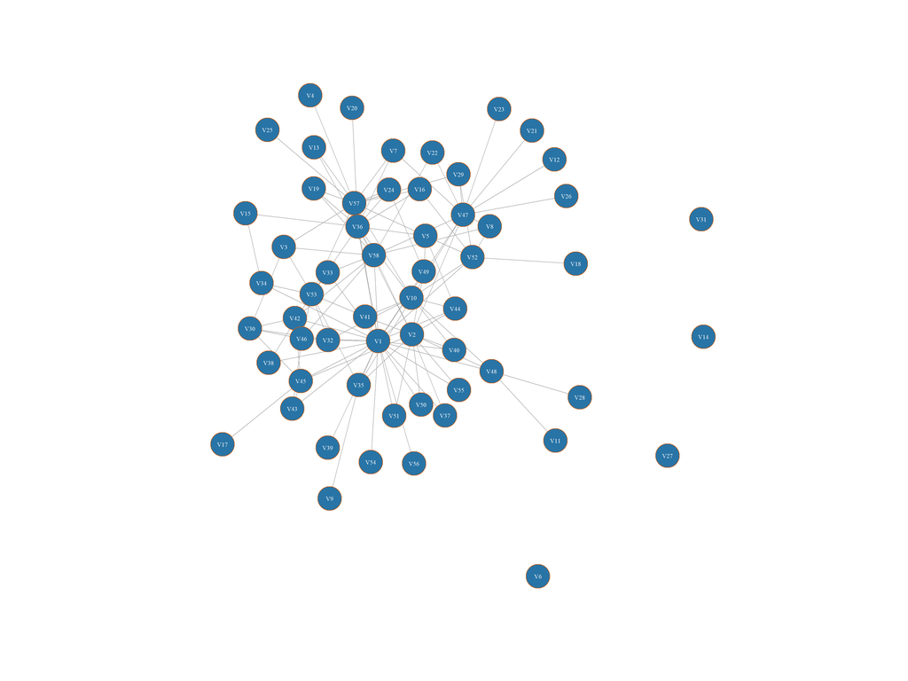

# Algoritmos graficas

### Algoritmo de Fruchterman-Reingold

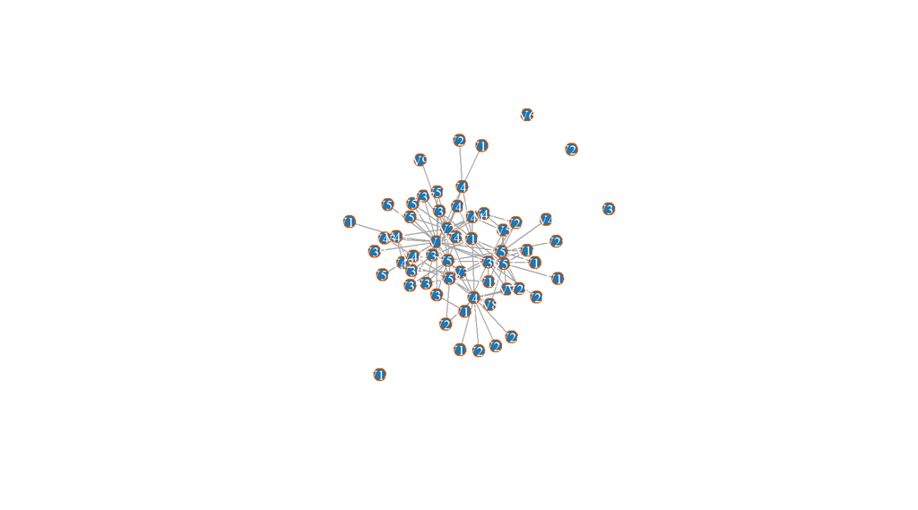

### Disposición jerárquica, como un árbol.

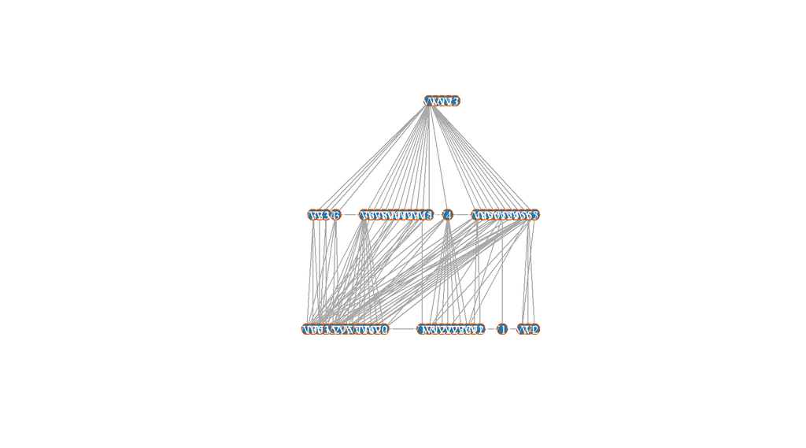

### Algoritmo DRL (Distributed Recursive Layout)

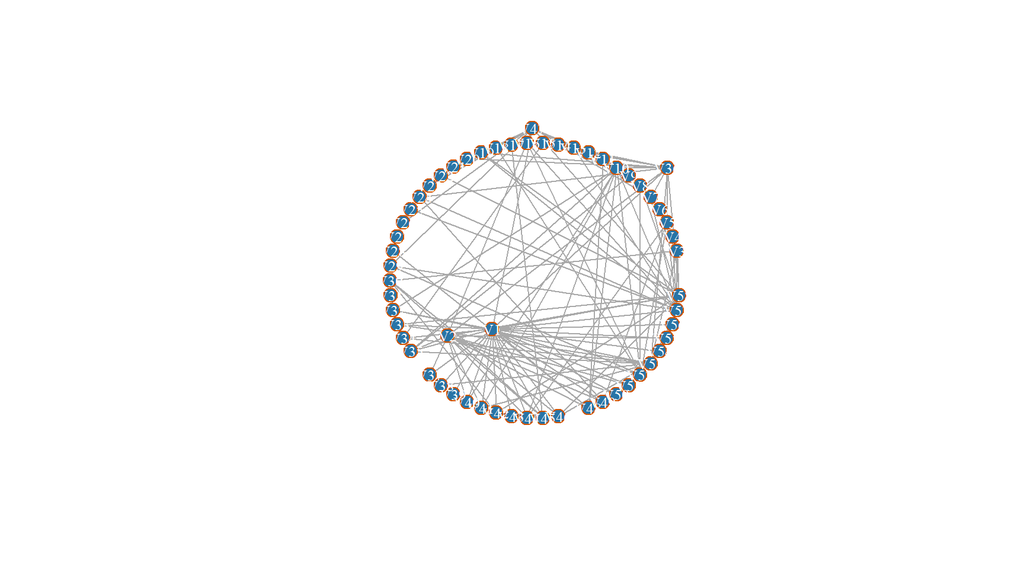

### Algoritmo físico optimizado.

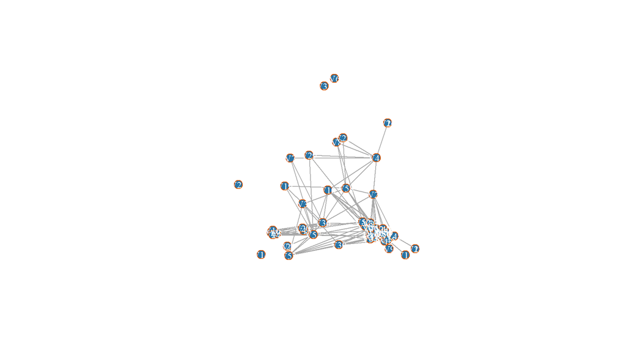

### De forma Aleatoria

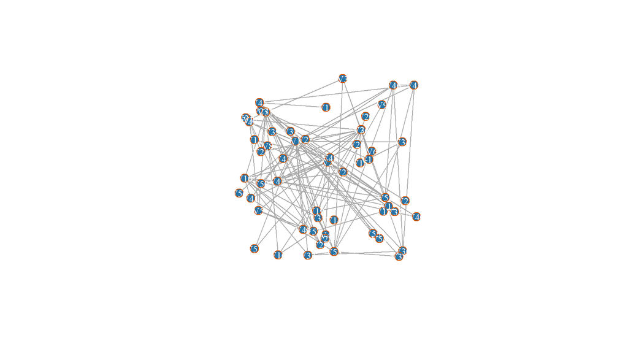